# DSS - Power Tips November 2020

Andriy Koval

11/29/2020

```r
library(magrittr)
library(dplyr)
library(ggplot2)
library(rlang)
```

# References

- [How to make your own ggplo2 functions](https://www.youtube.com/watch?v=9v9-EpTuwk0)
- [Tidy Eval Meets ggplot2](https://www.onceupondata.com/2018/07/06/ggplot-tidyeval/)
- [Tidy evaluation, most common actions](https://edwinth.github.io/blog/dplyr-recipes/)

# 1. Placing scales on all facets

When faceting a plot, we may need to place axis labels on each facet (especially if we have many of them):

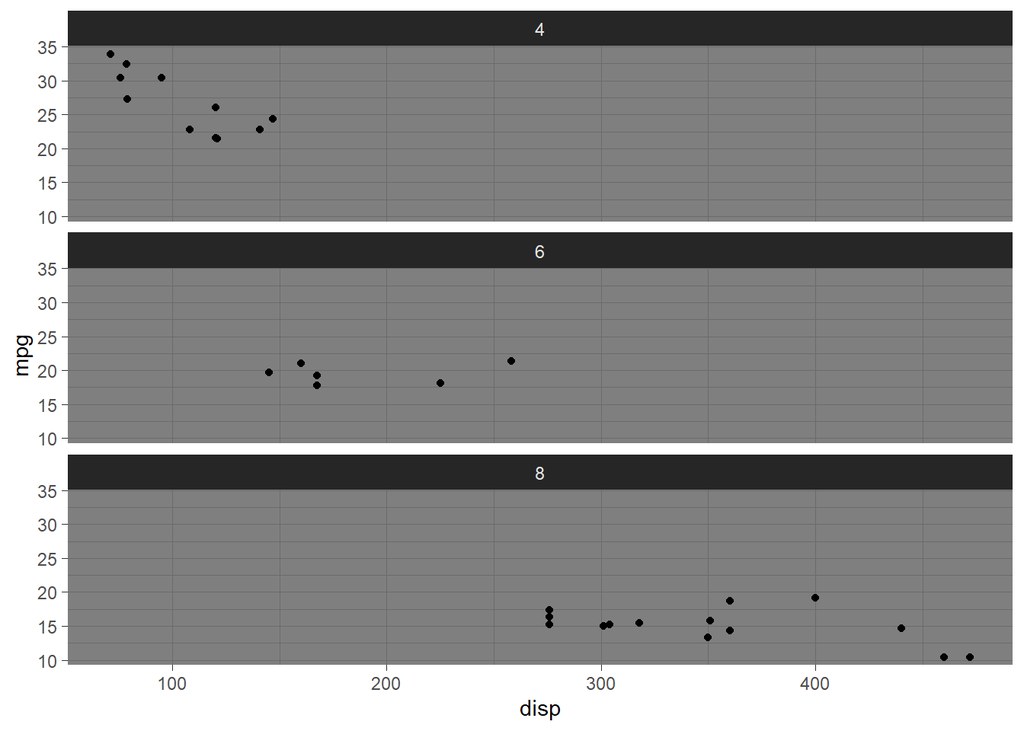

```r
mtcars %>%
  ggplot(aes(x=disp, y = mpg))+
  geom_point()+
  facet_wrap(~cyl, ncol=1)+
  theme_dark()
```

One way of achieving this is to use `scale = "free_x"` argument, but if data on the faceted levels covers different ranges of values, the limits of the scale will be adjusted:

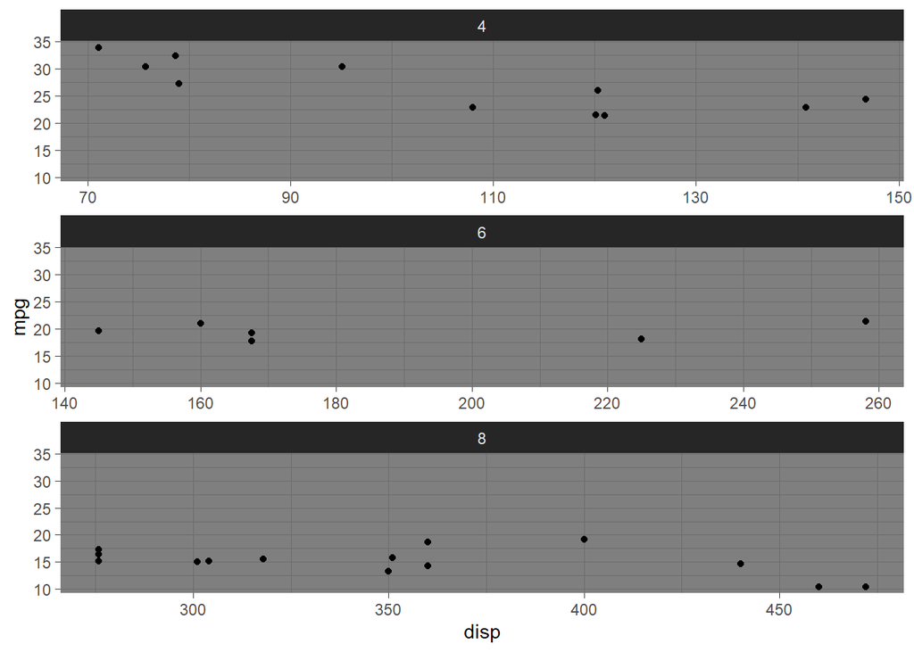

```r
mtcars %>%
  ggplot(aes(x=disp, y = mpg))+
  geom_point()+
  # facet_wrap(~cyl, ncol=1)
  facet_wrap(~cyl, ncol=1, scales = "free_x")+ # puts tickmarks, but distorts scale
  theme_dark()
```

Comes in the `lemon` package, which provides functions `racet_rep_wrap()` and `facet_rep_grid()` to offer exactly this flexibility. You can also use the arguments you normally pass to `facet_wrap()` or `facet_grid()` respectively:

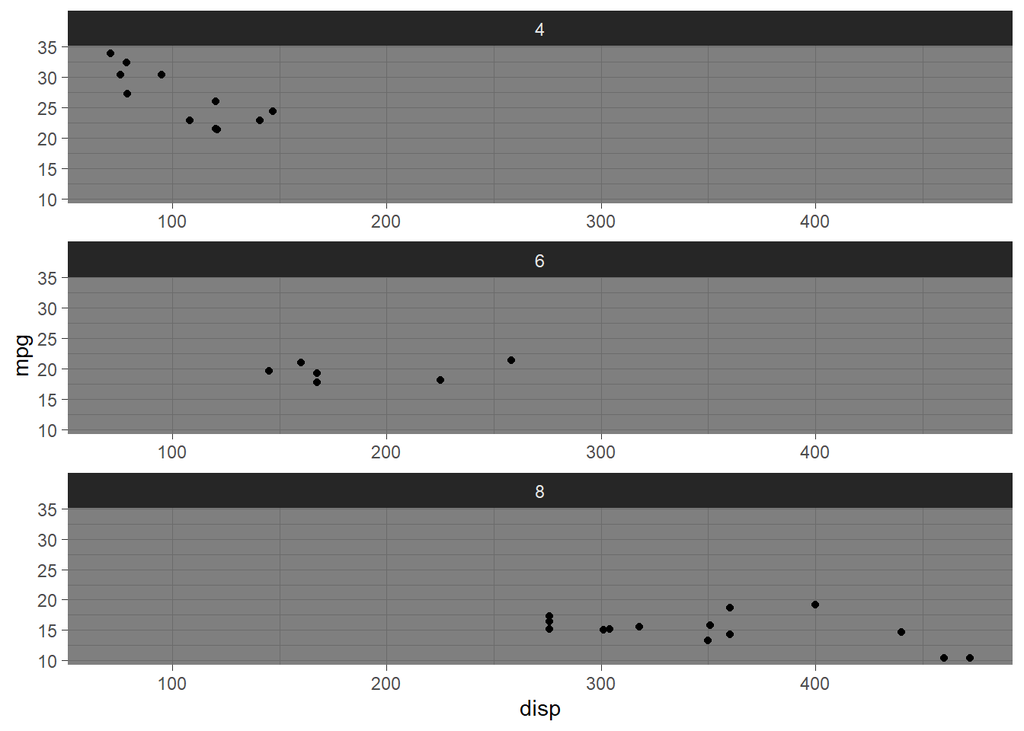

```r
mtcars %>%
  ggplot(aes(x=disp, y = mpg))+
  geom_point()+
  # facet_wrap(~cyl, ncol=1)
  # facet_wrap(~cyl, ncol=1, scales = "free_x") # puts tickmarks, but distorts scale
  lemon::facet_rep_wrap(~cyl,ncol=1, repeat.tick.labels = TRUE)+
  theme_dark()
```

# 2. Tidy Evals with {{

When turning your ggplots into functions, we can use `aes_string` funtion to pass quoted strings as variable names

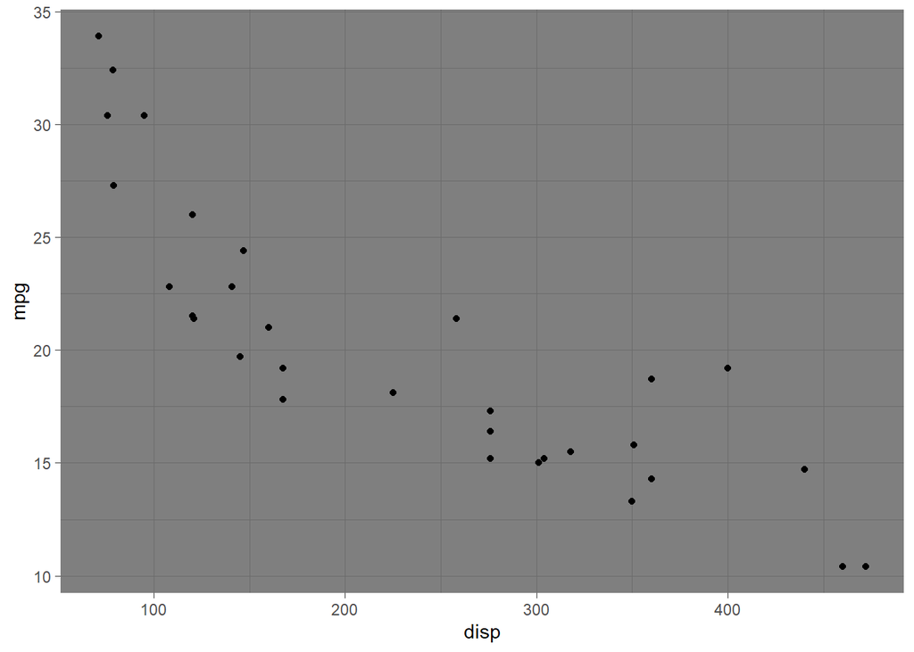

```r
make_faceted_scatter <- function(d,xvar,yvar){
  mtcars %>%
    ggplot(aes_string(x=xvar, y = yvar))+
    geom_point()+
    theme_dark()
}
mtcars %>% make_faceted_scatter("disp","mpg")
```

Unfortunately, this did not play well with facets. However, since `0.4.0` version, `rlang` provides a shortcut for this implementation using `{{}}`, which pairs up with the new (`ggplot2 3.0.0`) helper function `vars()` in `facet_wrap()` to make it work:

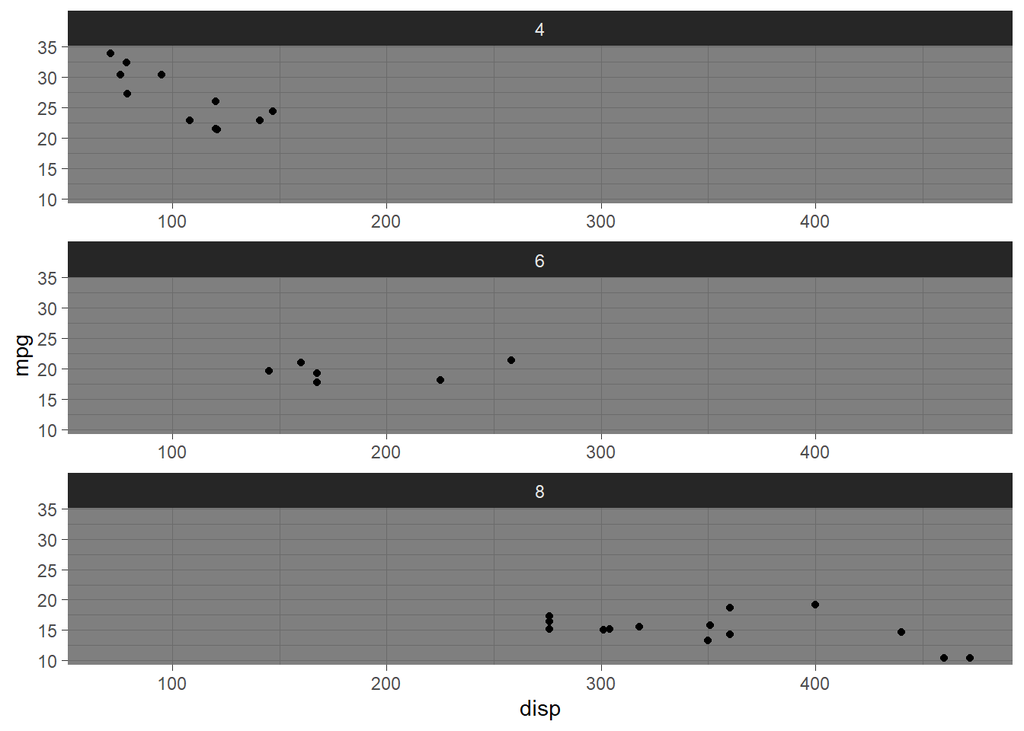

```r
library(rlang)
make_faceted_scatter <- function(d,xvar, yvar,fvar){
  mtcars %>%
    ggplot(aes(x={{xvar}}, y = {{yvar}}))+
    geom_point()+
    lemon::facet_rep_wrap(vars({{fvar}}),ncol=1, repeat.tick.labels = TRUE)+
    theme_dark()
}
mtcars %>% make_faceted_scatter(disp,mpg,cyl)
```